# Data munging: manejo de datos con R, the tidyverse way

Pedro J. Pérez (pedro.j.perez@uv.es). Universitat de València Web del curso: https://perezp44.github.io/intro-ds-20-21-web/

Noviembre de 2017 (actualizado el 16-11-2020)

# 1. Introducción

En el tutorial anterior aprendimos a cargar datos en R. Sin embargo, es difícil que en una aplicación real tengamos los datos tal y como los necesitamos para hacer nuestro análisis. Habitualmente tendremos que trabajar los datos para arreglarlos. Este proceso, que en castellano podría llamarse “limpieza” o **procesado de datos**, se conoce en inglés como **data munging or data wrangling**.

- hacer nuestros datos tidy
- arreglarlos para que sean útiles para nuestros propósitos

**Data wrangling** from http://r4ds.had.co.nz/wrangle-intro.html

Se suele decir que el procesado/limpieza de los datos suele ocupar un 80% del tiempo de un análisis de datos. Quizás sea una cifra un poco exagerada, pero, en cualquier caso, es una tarea que ocupa tiempo y que puede llegar a ser tediosa y frustrante si no se dispone de las **herramientas adecuadas**. Incluso datos que parecen que ya están trabajados es bastante fácil que tengamos que trabajarlos para adaptarlos a nuestras necesidades.

```r
Una secuencia "real" de tweets:

0930: How lucky I am to work on clean datasets curated by true professionals.
1330: Huh. Some inconsistencies here. No bigs. Ill just write up some quick and dirty regex to clean this up.

1720: I WILL BURN THIS HERETICAL DATA CENTER AND SCATTER ITS ASHES (traducción: me cago en todo lo que se menea)
```

En clase utilizamos datos reales, pero la verdad es que suelen ya estar casi limpios del todo. Estamos aprendiendo.

> Classroom data are like teddy bears; real data are like a grizzly with salmon blood dripping out its mouth. —- [@JennyBryan]

Como dice Albert Y. Kim en [estas transparencias](http://rpubs.com/rudeboybert/eCOTS_2018) los datos utilizados para aprender a manejar datos tienen que ser realistas pero sin llegar a ser intimidantes.

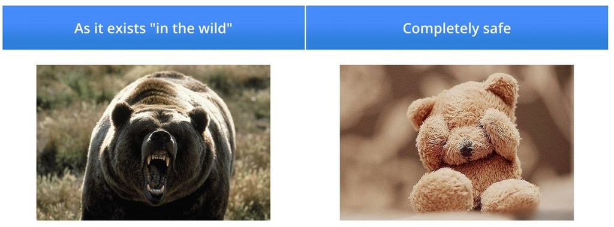

En este tutorial aprenderemos a limpiar y transformar datos en R. Priorizaremos la nueva forma de hacer las cosas en R (o workflow) conocido como **tidyverse**. En los últimos años se ha convertido, por varias razones, en el enfoque estándar; a pesar de ello, cada cierto tiempo vuelve a reabrirse el debate sobre cómo enseñar/aprender R y si es apropiado priorizar el tidyverse sobre R-base. [Aquí](https://twitter.com/kaija_bean/status/1217293396706054145) tienes un hilo de twitter donde se debate sobre este tema.

[Aquí](http://www.onthelambda.com/2014/02/10/how-dplyr-replaced-my-most-common-r-idioms/) tenéis un post sobre las diferencias entre las funciones de R-base y las del tidyverse para el procesado de datos, y [aquí](http://zevross.com/blog/2015/01/13/a-new-data-processing-workflow-for-r-dplyr-magrittr-tidyr-ggplot2/) otro post de un nuevo convencido de las bondades de esta nueva forma de manipular datos en R. Como ejemplo:

> Up until last year my R workflow was not dramatically different from when I started using R more than 10 years ago. Thanks to several R package authors, most notably Hadley Wickham, my workflow has changed for the better using dplyr, magrittr, tidyr and ggplot2. Given how much I’ve enjoyed the speed and clarity of the new workflow

## Tidyverse

#### ¿Qué es esto del tidyverse?

Con la palabra tidyverse se hace referencia a una “nueva” forma de afrontar el análisis de datos en R en la que se hace uso de **un grupo de paquetes que trabajan en armonía** porque comparten ciertos principios, como por ejemplo, la forma de estructurar los datos.

La mayoría de estos paquetes han sido desarrollados por (o al menos con la colaboración de) [Hadley Wickham](http://hadley.nz/). Esta es la [página web del tidyverse](https://www.tidyverse.org/)

No es necesario, pero si quieres conocer un poco mejor qué es el tidyverse, puedes hacerlo leyendo [The tidy tools manifesto](https://cran.r-project.org/web/packages/tidyverse/vignettes/manifesto.html). Está cita es un buen referente de la filosofía o enfoque del tidyverse

> Programs must be written for people to read, and only incidentally for machines to execute – Hal Abelson

Para continuar entendiendo qué es esto del tidyverse, citaré 2 de sus principios:

- Los scripts deben ser **“fácilmente” legibles por las personas**
- **Resolver problemas complejos** encadenando funciones simples con el **operador `%>%`**

## The pipe (`%>%`)

Este operador ocupa un lugar fundamental en el tidyverse. Permite resolver un problema complejo no de una sola vez, sino encadenando llamadas a funciones que se van encadenando con el operador `%>%`. Este operador facilita mucho la lectura e interpretación del código, ya que se van encadenando operaciones sencillas para, poco a poco, conseguir transformaciones de datos complejas. El **operador pipe** se lo debemos a Stefan Bache en su pkg magrittr.

[figure not shown]

En palabras, lo que hace este operador es **pasar el elemento que está a su izquierda como un argumento de la función que tiene a la derecha**. Así al principio parece complicado.

**Con expresiones** el operador pipe hace:

|  | – |  |
| --- | --- | --- |
| f(object, argumentos de la función) | ES EQUIVALENTE a | object %>% f(argumentos de la función) |
|  | – |  |

**Se entiende mejor con ejemplos sencillos**. Las siguientes dos instrucciones de R **hacen exactamente lo mismo**: permiten ver las 4 primeras filas del `penguins` dataset.

```r
library(palmerpenguins)

head(penguins, n = 4)         #- forma habitual de llamar/usar la función head()

penguins %>% head(. , n = 4)  #- usando el operador pipe
```

La primera expresión es la manera habitual de usar/llamar a la función `head()`. La segunda expresión es la sintaxis, la forma que hay que usar, si trabajamos con el operador pipe.

Así, a primera vista, parece que el operador `%>%` no supone ninguna ventaja, sólo es una forma distinta de ejecutar o llamar a una función, y a primera vista parece complicar las cosas. Sí, eso es cierto, si solo usas una función no tendría mucho sentido usar `%>%`, pero cuando tienes que hacer una sucesión de cálculos, una sucesión de llamadas a funciones, facilita mucho la lectura del código y por tanto el análisis. Lo vemos enseguida.

Para entender un poco más el funcionamiento de `%>%`, has de ver que estas tres instrucciones son equivalentes.

```r
head(penguins, n = 4)         #- forma habitual de llamar/usar la función head()

penguins %>% head(. , n = 4)  #- usando el operador pipe (con el punto actuando como placeholder)

penguins %>% head(n = 4)      #- usando el operador pipe (SIN el punto)
```

El punto de la segunda expresión señala, le dice a the pipe donde debe situarse el argumento de la izquierda dentro de la función; en nuestro ejemplo le dice a `%>%` que `penguins` debe situarse en el primer slot de `head()`. El punto `.` le está diciendo a `%>%` donde debe situarse `penguins`; es decir, el punto actúa, lo estamos usando, como un “placeholder”.

La tercera expresión también funciona porque si no usamos el punto (`.`), entonces, por defecto, el operador pipe situará `penguins` en el primer slot de la función, en nuestro caso situará a `penguins` en el primer slot de `head()`.

La forma más habitual es no poner el `.`; es decir, la tercera expresión. La razón es simplemente que se ahorra tiempo al escribir, aunque la segunda expresión es mucho más explicita, más descriptiva, de lo que hace el operador pipe.

Para casi terminar de entender la sintaxis del operador pipe. Intentad ver si entendéis la siguiente instrucción:

```r
4 %>% head(penguins, .)
```

Si no sabéis lo que hace, siempre podéis ejecutar la instrucción en la consola de RStudio.

Recuerda: Cuando usamos el operador pipe, tenemos obligatoriamente que usar el punto si queremos que el argumento de la izquierda se sitúe en un slot diferente del primer slot

Para acabar nuestro repaso a `%>%` mirad por qué no funciona la siguiente instrucción:

```r
4 %>% head(penguins)
```

El operador pipe quiere llevar el `4` al primer slot de `head()` ya que si no ponemos el punto, ese es su comportamiento por defecto. Sin embargo, al ejecutar la expresión, el interprete de R nos devuelve un mensaje de error. ¿Por qué? Tendrás que mirar la ayuda de la función con `help(head)`.

Aún no sabemos muy bien cuál es su utilidad, pero ya conocemos la sintaxis de `%>%`. Lo que hace que este operador sea tan útil es que **las pipes se pueden encadenar**.

El operador pipe podemos leerlo como **“*entonces*”** y permite encadenar sucesivas llamadas a funciones. Por ejemplo:

```r
penguins %>% filter(sex == "female") %>%
             group_by(species) %>%
             summarise(peso_medio = mean(body_mass_g))
```

La anterior linea de código R hace:

1. coge los datos de pingüinos y selecciona (o filtra) las filas/pinguinos cuyo valor de la variable `sex` es female; es decir, seleccionamos los pingüinos hembras, *entonces* (o después)
2. agrupa los datos/pingüinos por la variable `species`, *entonces*
3. calcula la media de `body_mass_g`

En conjunto, encadenando las 3 funciones hemos seleccionado las filas que pertenecen a pingüinos hembras, hemos agrupado las pingüino hembras en función de su especie (hay 3 especies de pingüinos) y calculado el peso medio de cada uno de las 3 especies de pingüinos; es decir, hemos calculado el peso medio de las pingüinos hembra en cada uno de las tres especies de pingüinos.

Con esta nueva sintaxis (que permite el operador pipe) ya no necesitamos anidar funciones, sino que las instrucciones van una después de otra. Es **mucho más fácil de leer y de escribir**. Esta idea de que es mucho más fácil escribir à la tidyverse no se llega a apreciar con los ejemplos que hemos hecho en esta sección, pero se hará evidente cuando empecemos a encadenar operaciones con dplyr. Como ejemplo este tweet.

> I used this idea today for teaching [#rstats](https://twitter.com/hashtag/rstats?src=hash&ref_src=twsrc%5Etfw) pipes and 🤞hopefully it helped? 🤞 https://t.co/XnpsIw96Hw [pic.twitter.com/6sAmM4FDRy](https://t.co/6sAmM4FDRy)

> — Andrew Heiss (@andrewheiss) [September 16, 2019](https://twitter.com/andrewheiss/status/1173743447171354624?ref_src=twsrc%5Etfw)

No te va a resultar sencillo porque no sabes que es `letters`, ni `paste0()`, ni `toupper()`, pero intenta entender por ti mismo que hace la siguiente linea de código. ya sabes que siempre puedes ejecutarla y ver que hace, y mucho mejor si la ejecutas por trozos para ir viendo poco a poco qué hace:

```r
letters %>% paste0( "-----" ,  .  ,  "!!!" ) %>% toupper
```

#### Un poco más acerca de the pipe (`%>%`) [OPCIONAL]

De forma más técnica. Aquí podéis ver el funcionamiento del operador pipe:

```r
library("magrittr")

#-------- Rule 1
f(xx)     es equivalente a     xx %>% f

#-------- Rule 2
g(xx, n = 5)
xx %>% g(n = 5)

#-------- Rule 3
g(f(xx), n = 5)
xx %>% f %>% g(n = 5)

Se lee como "Take xx then do f then do g with n = 5".

#-------- Rule 4
f(y, x)
x %>% f(y, .)

#-------- Rule 5
f(y, z = x)
x %>% f(y, z = .)

#(!!!!)------------- BONUS: The input to the pipeline can itself be a placeholder!!
num_unique <- . %>% unique %>% length

num_unique(iris$Species)

iris$Species %>% num_unique

-----

num_unique es equivalente a : f <- function(.) length(unique(.))
```

Un buen recurso para aprender el uso de `%>%` son [estas transparencias](https://teachthat.netlify.app/pipe/#1). Una exposición más detallada de la sintaxis y posibilidades del operador `%>%`, así como la de otros operadores como `%T>%` y `%<>%` puedes encontrarla [aquí](https://www.rdocumentation.org/packages/magrittr/versions/1.5).

The **“tee pipe”** (`%T>%`) permite hacer cosas como esta:

```r
#- !!!!!!
rnorm(200) %>% matrix(ncol = 2) %T>%
plot %>% # plot usually does not return anything.
colSums
```

The **“tee pipe”**, como el pipe original, pasa el argumento de la izquierda a la función de la derecha, PERO devuelve el propio valor original, no devuelve el resultado de la evaluación de la función. Como se señala [aquí](https://magrittr.tidyverse.org/reference/tee.html), este comportamiento es útil cuando se usa la función por sus side-effects; es decir, para imprimir o graficar. Yo la utilidad que le veo es hacer chequeos dentro de una secuencia de pipes, como por ejemplo hacen en [este tweet](https://twitter.com/lepovas/status/1283411774134538251)

The **“exposition pipe”** (`%$%`) también del pkg `magrittr`. En [este post](https://thewoodpeckr.wordpress.com/2020/02/10/upping-your-pipe-game/) nos explican su utilidad. Pero solo leedlo cuando ya seáis usuarios intermedios de R. Sirve para hacer accesibles las columnas de un dataframe a funciones que no admiten dataframes como la función `cor()`. De esta forma podemos integrar en nuestro pipeline funciones que no están preparadas para el tidyverse.

```r
#- !!!
library(magrittr)
iris %>% mean(Sepal.Length)   #- no funciona
iris %$% mean(Sepal.Length)   #- con the exposition pipe sí funciona

iris %>% cor(Sepal.Length, Sepal.Width)  #- no funciona
iris %$% cor(Sepal.Length, Sepal.Width)
```

Si no usásemos este nueva pipe, tendríamos que hacer lo siguiente:

```r
cor(iris$Sepal.Length, iris$Sepal.Width)
```

Muchas funciones de R-base no están preparadas para trabajar con el operador pipe. Son funciones que se escribieron antes de que se creara `%>%`. Se puede tratar de reescribir código en “R-base” usando `%>%` pero no tiene mucho sentido y no es muy agradable; sin embargo si se trabaja con el tidyverse, utilizar the pipe hace la sintaxis muy fluida. Como ejemplo de esto el siguiente chunk:

```r
library(tidyverse)

x1 <- c(-5:5, NA)  #- es un vector

#- escribiendo à la R-base
mean(x1[x1>0], na.rm = TRUE)   #-  calcula la media de los valores positivos de x1
sum(x1[!is.na(x1)])            #-  calcula la suma de los valores de x1 que no son NA

#- ahora haremos lo mismo, seguimos usando R-base, pero con el operador pipe (!!!!)
x1 %>% .[.>0] %>% mean(., na.rm = TRUE)
x1 %>% .[!is.na(.)]  %>% sum

#- podríamos trabajar con data.frames usando the exposition pipe
df <- as.data.frame(x1)   #- tidyverse usa data.frames
df %$% x1 %>% .[.>0] %>% mean(., na.rm = TRUE)
df %$% x1 %>% .[!is.na(.)]  %>% sum

#- con tydiverse
df <- as.data.frame(x1)   #- tidyverse usa data.frames
df %>% filter(x1 > 0) %>% summarise(mean_x1 = mean(x1, na.rm = TRUE))
df %>% filter(!is.na(x1)) %>% summarise(suma_x1 = sum(x1))
```

Bien, ya sabemos como funciona “the pipe”. Volvamos al tidyverse y a aprender a manipular datos en R.

## Principales pkgs del tidyverse

Como puede verse en su [página web](https://www.tidyverse.org/), los principales packages del tidyverse son:

[figure not shown]

- `readr`: para importar datos
- `tidyr`: para convertir los datos a tidy data
- `dplyr`: para manipular datos
- `ggplot2`: para hacer gráficos
- `tibble`: data frames actualizados
- `forcast`: para manipular factores
- `stringr`: para manipular strings
- `purrr`: para functional programming
- y algunos más

Nos centraremos en los **cuatro primeros paquetes**, principalmente en `dplyr` y `ggplot2`.

Los principales paquetes del tidyverse se han “agrupado” en un metapaquete llamado `tidyverse`, así que cuando ejecutas `library(tidyverse)` en realidad estás cargando varios paquetes del tidyverse